# Does the news predict the stock market or simply report on it?

### Eric Robertson

[figure not shown]

# Overview

### What is the aim of this project?

Its always a go-to data science question of using news data to predict stock price. I myself have gone through that activity multiple times, but the underlying assumption is that in some way news about stocks predicts price of stock. I wanted to examine that trend more. Youtube specificly has a large collection of independent financial channels on youtube who report on many stock trends and often make reccomendations about what stocks to buy and what they are investing in. These communities have sprung up noteably over the last few years and Id recon they have a decent amount of swing on the market as a whole. My goal is to explore this relationship and see how so-called `hot stocks` are formed and possibly predict them.

### What value does this project actually provide?

Certainly stock prediction is devorced from a lot of value that other datasets may provide, but in this example it will be a good chance to look more into the news cycle and how the naritave produces by news (specificly those on youtube) is influenced by outside factors. What causes the naritave to change and how does the naritave influence the world outside of it.

### What data and tools are used for the project?

Youtube has a very active group of independent financial / stock channels which follow stocks and often publish frequently about financial news. Using the Youtube video api we will be collecting a large collection of recent video information and using it to coorlate with daily stock data over the last few years.

`Youtube` Youtube channels for this dataset were hand chosen by me due to youtubes lack of robust ability to objectively rank chanel views and cataglories. This certainly adds some bias into the data and results, but I will explore that more as I move throught the project.

`Stocks` Stocks to compair channels with were also hand selected, but I aimed to incorperate a broad range of stocks to help with analysis. This also produces bias, but the hope is that with a large enough collection I am able to produce a good sample of results.

# Libraries used for the project

```python
# Build in stuff
import requests
import json
import os
import datetime

# Data Manipulation
import pandas as pd
import numpy as np
import ast

# Plotting
import matplotlib.pylab as plt
import matplotlib.dates as mdates
from IPython.display import JSON
import matplotlib.ticker as ticker

# Data analysis
import scipy.stats as stats
```

# Getting Data

## Loading data from Youtube API

Since we want to use youtube for video data we will be using the official youtube data api through google develop console. I have obtained a set of api keys for myself for this project that will not be public on this repo for security reasons.

To obtain your own / to further explore the youtube api, look [here](https://developers.google.com/youtube/v3/getting-started). We will be sticking with basic operations, but it is quite powerful.

```python
# To load api_keys and do a few other utility functions i wrote in another file
# This is mainly for security, not trying to publish api keys
import source.util as util

# Lets explore some of the functionality we are looking for
youtube_api_base = "https://www.googleapis.com/youtube/v3"

# Pull in keys saved as text file
youtube_api_keys = util.load_api_keys()
_key = 12
```

```python
# Examining API

def youtube_api_parse ( response ) :
    return json.loads(response.text.encode("ascii", "ignore").decode("utf-8"))['items']

def youtube_api_search_for_channel ( channel_search ):
    return youtube_api_parse(
        requests.get( f"{youtube_api_base}/search?part=id%2Csnippet&q={channel_search}&type=channel&key={youtube_api_keys[_key]}"))
```

```python
# Lets use the api for a generic search
_ = youtube_api_search_for_channel('University of Maryland School of Music')[0]
JSON( _ )
```

```python
# Specificly we want youtube videos and their metadata though

# Search for a channel id given name
def youtube_api_channelID ( channel_search ):
    return youtube_api_search_for_channel( channel_search )[0]['id']['channelId']

# Get video ids given channel id
def youtube_api_videoIDs ( channel_id ):
    results = youtube_api_parse(
        requests.get( f"{youtube_api_base}/search?key={youtube_api_keys[_key]}&channelId={channel_id}&part=snippet,id&order=date&maxResults=20"))
    video_ids = [ a['id']['videoId'] for a in results if a['id']['kind'] == 'youtube#video' ]
    return video_ids

# Get video meta data given video id
def youtube_api_videoMeta ( video_id ):
    return youtube_api_parse(
        requests.get( f"{youtube_api_base}/videos?part=snippet,statistics&id={video_id}&key={youtube_api_keys[_key]} "))

# Pull it all together
def youtube_api_load_videos ( channel_search ):
    channelID = youtube_api_channelID( channel_search )
    videoIDs = youtube_api_videoIDs( channelID )

    return youtube_api_videoMeta ( videoIDs [0]  )
```

```python
# Pull all the data together
_ = youtube_api_load_videos('University of Maryland School of Music')[0]
JSON( _ )
```

### Choice of channels

Great! so we now have the ability to pull in all the data about every youtube video. We now need a list of channels to use for this analysis. Since this is ment to be an exploration of youtube videos and the stock market, I have chosen a variety of channels These choises are likely bias due to the nature of youtube recomendations, but it was the best I could do searching around for a variety of stock-market related content creators.

`Swing Traders` These channels are focused on short term gains, following every hot stock and giving predictions on how a single stock will do in the next few days or weeks. Its likely these channels focus on a small group of stocks each and have high degree of overlap.

| 40 Finance | Adriana Gorrin | Andy's FIRE Club | Carter Farr |  |
| --- | --- | --- | --- | --- |
| Financial Health | George Perez | Jack Spencer Investing | Joey Choy |  |
| Market Gains | Matthew Huo | StockMoe | TechConversations |  |
| Tom Nash |  |  |  |  |

`Tecnicals` These chanels are focused on technology and technical indicators. They report changes in prices and trading paterns and algorithms. Often they promote options or cripto currency aswell.

| Altcoin Daily | DataDash | Kaswrp | StockedUp - Mike D'Antonio |  |
| --- | --- | --- | --- | --- |
| The Kendall Report | TouchdownTrades | Trading Fraternity | True Trading Group |  |
| US vs HERD |  |  |  |  |

`Personal Finance` These channels focus on their own financial journey, their business investments and more conservative personal financial goals. They are more the personalities behind financial education and promoting people follow their causious footsteps.

| Andrei Jikh | ClearValue Tax | GrahamStephan | Joseph Carlson |  |
| --- | --- | --- | --- | --- |
| Joseph Carlson Clips | Meet Kevin | TaylorBarnes907 | The Money Guy Show |  |

`Mainstream` These are the representation of the mainstream news channels and financial institutions

[output not shown]

Certainly combining a variety of different channels that all operate in different ways can muddy the data, but the hope is with enough diverse data point and some work put into pre-processing the data we should be able to get good conclusions even with the variety of differnt videos. Each channel will have its own style but they are all financial related so the topics are not that vastly different. We will have to see what extent we can work with them

### Processing of channel data

```python
# Load a script to do the api calls above and save the results into files
import source.data as data_scraper

# The above channels are loaded from a text file
target_channels = util.load_channel_names()
str(len(target_channels)) + ' names loaded from text file'
```

```
'35 names loaded from text file'
```

```python
# Saves all the data downloaded into the youtube_data directory for later use
# To process the whole channel list, will likely take 20+ api tokens ( each one has a limited request amount )
# Now that is a lot of google developer accounts lol

# May take quite a while
for i,channel in enumerate(target_channels):
    data_scraper.youtube_api_load_videos(channel)
    print(f"Finsihed with {channel} ({i} / {len(channel)})".ljust(50, ' '), end='\r')

print(f"Finished with all {len(target_channels)}!".ljust(100,' '), end='\r')
```

```
Finished with all 35!
```

## Loading Stocks from alphavantage api

To give a good relation to our youtube financial data, we can access stock market daily prices. We will save them now for future use

```python
# Using alphavantage api for this one, agian, hidden for privacy
alphavantage_api = util.load_stock_api()

# Requesting stock data is simple
def alphavantage_load_stock ( stock ) :
    response = requests.get(f"https://www.alphavantage.co/query?function=TIME_SERIES_DAILY_ADJUSTED&symbol={stock}&apikey={alphavantage_api}&outputsize=full")
    return json.loads( response.text )

alphavantage_load_stock("AAPL")['Time Series (Daily)']['2020-12-09']
```

```
{'1. open': '124.53',
 '2. high': '125.95',
 '3. low': '121.0',
 '4. close': '121.78',
 '5. adjusted close': '121.78',
 '6. volume': '115089193',
 '7. dividend amount': '0.0000',
 '8. split coefficient': '1.0'}
```

```python
# Package it up for easy consumption
def download_stock ( stock ):
    outfile = f"stock_data/{stock}.json"
    if os.path.exists(outfile): return
    stock_data = alphavantage_load_stock( stock )
    with open(outfile, 'w') as outfile:
        outfile.write(json.dumps(stock_data))
    print(f"Loaded {len(stock_data['Time Series (Daily)'])} days of data for {stock}".ljust(100,' '))
```

```python
# Selecting a few key stocks to compair to later, mostly techy stocks as that is what these channels focus on
target_stocks = ['NIO', 'WKHS', 'TSLA', 'AAPL', 'HYLN', 'SHLL', 'AMZN', 'DPHC', 'FB', 'SPY', 'MSFT', 'GOOGL', 'F', 'WYNN', 'INTC', 'SQ', 'ETSY', 'NVDA', 'SHOP', 'MRNA', 'JNJ', 'LMND']
for stock in target_stocks:
    download_stock( stock )
print(f"Saved {len(target_stocks)} stocks to local files")
```

```
Saved 22 stocks to local files
```

# Data Processing

The above steps dumped a lot of json files into our local directory, we need to sweep throught them and produce some sort of useful relation from them

## Youtube Videos

```python
# Both the stock data any youtube data in its current form is hard to work with, cleaning it up into cleaner tables to be used later
# Cleaning up youtube videos first

def load_video_paths ( channel ):
    path = f"./youtube_data/{channel}"
    return [ f"{path}/videos/{_}" for _ in os.listdir(f"{path}/videos") ]

def load_video_data ( video_path ):
    return util.load_json( video_path )

def pullValue ( data, value, default ):
    return data[value] if value in data else default

# Clean up the video
def extract_video_data ( data ):

    response = {}
    videoData = data['items'][0]
    snippet  = videoData['snippet']

    response['id'] = videoData['id']
    response['date'] = snippet['publishedAt'][:10]
    response['title'] = snippet['title']
    response['description'] = snippet['description']
    response['channelTitle'] = snippet['channelTitle']
    response['tags'] = pullValue( snippet, 'tags', ['untagged'])
    response['views'] = pullValue( videoData['statistics'], 'viewCount', 0)
    response['likes'] = pullValue( videoData['statistics'], 'likeCount', 0)
    response['dislikes'] =  pullValue( videoData['statistics'], 'dislikeCount', 0)
    response['commentCount'] = pullValue( videoData['statistics'], 'commentCount', 0)

    return response
```

```python
# Running the above functions show a much cleaner video output
example = target_channels[0]

example_video = load_video_data( load_video_paths( example )[0] )
clean_video = extract_video_data( example_video )

JSON( clean_video )
```

```python
# Running this on all videos
for channel in target_channels:

    if os.path.exists(f"./youtube_data/{channel}/clean.cvs"):
        continue

    videos = load_video_paths( channel )
    output_data = []

    for video in videos:
        video_data = load_video_data( video )
        video_clean = extract_video_data( video_data )
        output_data.append( video_clean )

    # Save the data out to a file
    _ = pd.DataFrame( output_data )
    _['date'] = pd.to_datetime(_['date'])
    _ = _.set_index('date').sort_index()
    _.to_csv( f"./youtube_data/{channel}/clean.cvs" )

    print(f'Cleaned {channel}'.ljust(100,' '), end='\r')

print( f'Processed all {len( target_channels)} channels')
```

```
Processed all 35 channels
```

## Stock Data

```python
# For this dataset we really only care about the stock data for the last 3 years and the closing prices
def process_stocks () :

    prices = []
    index_loaded = False

    for stock in target_stocks:
        # Taking only the daily data from the last few years
        frame = pd.DataFrame(util.load_json( f'./stock_data/{stock}.json' )['Time Series (Daily)']).T
        frame = frame[ frame.index > '2017-01-01']

        # Taking only the close price
        frame = frame['5. adjusted close']
        prices.append( frame )

    clean_stocks = pd.DataFrame(prices).T
    clean_stocks.columns = target_stocks
    clean_stocks.to_csv( f"./stock_data/clean.csv" )

    return clean_stocks
```

```python
# Do the processing if you havent yet
if not os.path.exists("./stock_data/clean.csv"):
    process_stocks()

print("Stock Data Processed")
```

```
Stock Data Processed
```

# Dataset overview

## Channel Publications

Taking a break here for a moment, lets assess what we have done so far. We now have saved to our computer the stock prices of a select group of stocks over the last few years. In addition we have a collection of thousands of youtube videos worth of meta data ( title, description, likes, tags, ect ... ) from specificly stock focused independendt content creators on youtube who promote investing. The hope is that we can use this video dataset to draw relations between the reports these channels produce and the stock prices recorded.

```python
# lets first look at the range of videos we have gotten
range_data = []

for channel in target_channels:
    data = pd.read_csv( f"./youtube_data/{channel}/clean.cvs" )
    date_range = pd.to_datetime(data['date'])
    range_data.append([ channel, date_range.min(), date_range.max() ])

range_data = pd.DataFrame(range_data, columns=['channel', 'oldest', 'recent']).sort_values(by='oldest', ascending=False)
range_data.head()
```

|  | channel | oldest | recent |
| --- | --- | --- | --- |
| 26 | Joseph Carlson Clips | 2020-12-10 | 2020-12-10 |
| 4 | Financial Health | 2020-08-22 | 2020-12-09 |
| 10 | StockMoe | 2020-08-17 | 2020-12-10 |
| 8 | Market Gains | 2020-06-20 | 2020-12-10 |
| 9 | Matthew Huo | 2020-04-14 | 2020-12-09 |

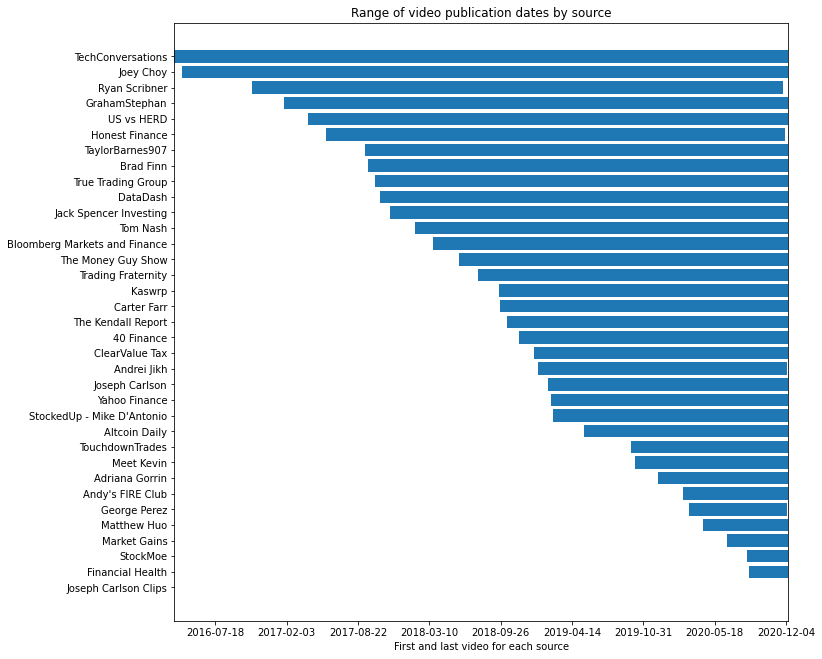

```python
# Clearly we have a range of publication dates from all of our sources
# Publication dates are all over the place because of the variety of sources pulled and the limit on video counts.
# Since videos were pulled from newest to oldest, we have a lot of recent data that peters off over time
fig, ax = plt.subplots()
plt.barh(range_data['channel'], width=(range_data['recent']-range_data['oldest']), left=range_data['oldest'])
ax.xaxis.set_major_formatter(mdates.DateFormatter('%Y-%m-%d'))
fig.set_size_inches(11,11)
plt.title('Range of video publication dates by source')
plt.xlabel('First and last video for each source')
```

We can see above that we have a huge range of publication dates. From channels with more than 4 years of video data and some with just a few weeks. There has been a big boom in financial channels over the last few months and years so its not a major surprise to see such a range, but its important to note this as we move forward.

## Video Tags

Now, to explore how trends are changing over time, lets look at popularities of various tags over the dataset. Just because a tag shows up, doesnt mean it actually has engagement or reach. To help judge the reach of a particular tag, ill be weighting various metrics. More information can be seen here: https://blog.hootsuite.com/calculate-engagement-rate/ as to how / why I chose what i did

The intent of this analysis is to see how videos and stocks coorilate. The connection there is that videos sway popular opinion or on other ways are a product of it. Thus, we dont care about the specific quantity of videos, but the social impact of each video. How much did each video impact the collective conscious. Thats a hard question, but one aproach is to measure its engagement for a stand in for popularity.

Below I give each video a `weight` that represents how impactful the video was. It is calculated by:

`weight` = `views` + `net likes` *20 + `comments`* 100

The rational is that likes indicate higher engagement than just views, and comments even more engagement. Certainly these weights can be adjusted but this is what will be used as `weight` of a video for this project.

```python
# Process tag data
def generate_tag_representation () :
    tag_data = []
    for channel in target_channels:
        data = pd.read_csv( f"./youtube_data/{channel}/clean.cvs" )
        for i,row in data.iterrows():
            # Weight the tags basted on engagement
            weight = row['views'] + (row['likes'] - row['dislikes']) * 20 + row['commentCount'] * 100
            for tag in ast.literal_eval(row['tags']):
                tag_data.append(( row['date'], row['channelTitle'], row['id'], tag, weight ))
        print(f"{channel} loaded".ljust(100,' '), end='\r')

    # Merge into data frame
    tag_data = pd.DataFrame(tag_data, columns=['date', 'channel', 'vid', 'tag', 'weight'] )

    # Clean up the tags for later use
    tag_data['tag'] = tag_data['tag'].str.replace(r'[^A-Za-z]', '').str.lower()

    # Save back out
    tag_data.to_csv( f"./youtube_data/tag_view.csv" )
```

```python
# Loading up all the tags shows there is quite the large collection of data points ( over 200K Rows! )
if not os.path.exists("./youtube_data/tag_view.csv"):
    generate_tag_representation()

tag_representation =  pd.read_csv( "./youtube_data/tag_view.csv" ).set_index('date')
tag_representation.index = pd.to_datetime(tag_representation.index)
tag_representation
```

| date | Unnamed: 0 | channel | vid | tag | weight |
| --- | --- | --- | --- | --- | --- |
| 2018-11-16 | 0 | 40 Finance | mQMkBhl6zFo | personalfinance | 389 |
| 2018-11-16 | 1 | 40 Finance | mQMkBhl6zFo | techstocks | 389 |
| 2018-11-16 | 2 | 40 Finance | mQMkBhl6zFo | financialplanning | 389 |
| 2018-11-25 | 3 | 40 Finance | 4u62lRmWlq8 | stockmarket | 177 |
| 2018-11-25 | 4 | 40 Finance | 4u62lRmWlq8 | investing | 177 |
| ... | ... | ... | ... | ... | ... |
| 2020-12-02 | 225810 | Honest Finance | fA_pAI3YFig | whenaredividendspaidout | 2517 |
| 2020-12-02 | 225811 | Honest Finance | fA_pAI3YFig | whenaredividendsissued | 2517 |
| 2020-12-02 | 225812 | Honest Finance | fA_pAI3YFig | stockmarketinvesting | 2517 |
| 2020-12-02 | 225813 | Honest Finance | fA_pAI3YFig | dividendinvesting | 2517 |
| 2020-12-02 | 225814 | Honest Finance | fA_pAI3YFig | investingterms | 2517 |

225815 rows × 5 columns

# Normalization

We have much more organized data so far, but its still quite skewed for various reasons. Lets explore why and see if we can correct them.

## Tags by day

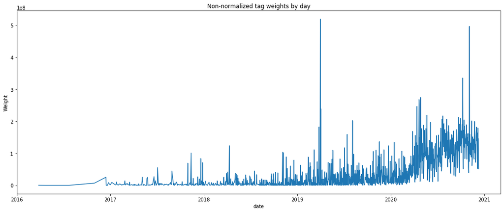

```python
# See how the weight per-day is skewed forward
def plot_normalization_chart ( data, title = "" ):
    fig, ax = plt.subplots()
    plt.plot( data)
    ax.set(title=title, xlabel='date', ylabel='Weight')
    fig.set_size_inches(18,7)

_ = tag_representation.groupby('date').sum()
plot_normalization_chart( _.weight, title="Non-normalized tag weights by day")
```

Above it is clear that the weight of the tags are rising with time, in part because we have more samples for closer dates. To alleviate this we can divide by the number of videos published each day to help remove the bias from more videos being produced. In addition, the number of videos published from ealier dates is so few that many days lack video data at all. To help with this, we can fill any null date with 0s or remove them from the data set.

```python
# Since some days dont have data to report, lets fill them with 0s for now
def fill_empty_dates (df):
    dates = pd.date_range(df.index.min(), df.index.max())
    return df.reindex(dates)
```

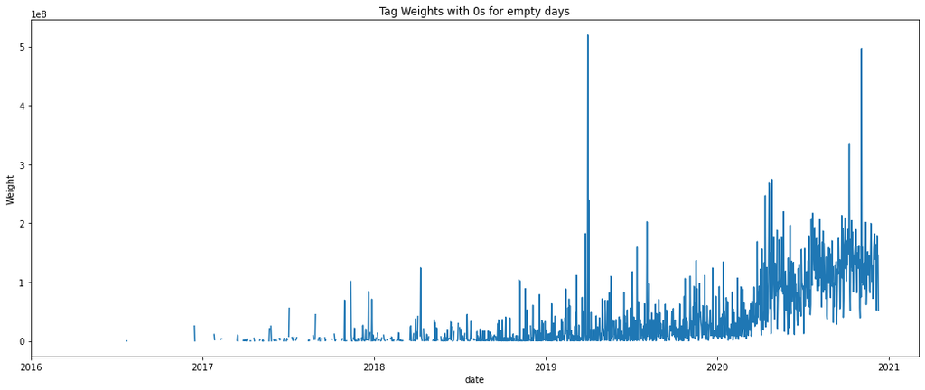

```python
# Showing only the days we have data for shows the massive inequality of data over time
_ = fill_empty_dates( tag_representation.groupby('date').sum() )
plot_normalization_chart( _.weight, title="Tag Weights with 0s for empty days")
```

```python
# First, lets divide each day by the actual number of records for that day to get a more normalized representation
_sum = tag_representation.groupby('date').sum()
_count = tag_representation.groupby('date').count()

# Divide by number of videos
_ = pd.DataFrame({ "vids": _count['vid'], "weight": _sum['weight']})
_ ['ave'] = _['weight'] / _['vids']

# Fill empty dates with 0 (unfilled) or with more recent value (filled)
_unfilled = fill_empty_dates(_)
_filled = fill_empty_dates(_).fillna(method='ffill')

_filled.to_csv('./youtube_data/daily_weight.csv')
```

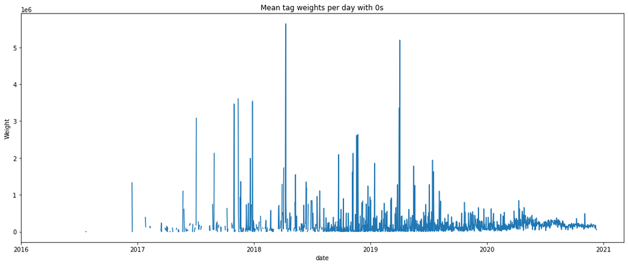

```python
plot_normalization_chart( _unfilled.ave, title="Mean tag weights per day with 0s" )
```

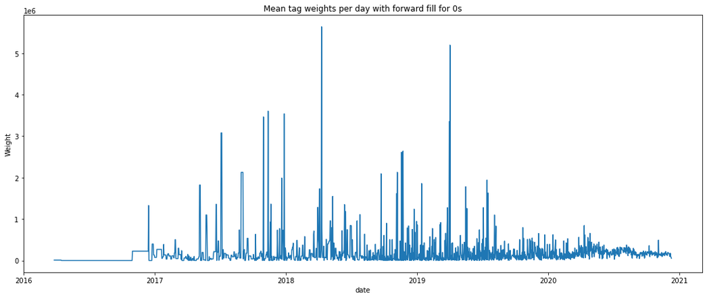

```python
plot_normalization_chart( _filled.ave, title="Mean tag weights per day with forward fill for 0s" )
```

We are still running into issues though, certainly if we get a viral video followed by a gap in the dataset we find a huge skew. However, leaving days with 0s really doesnt help because when we consider video data, its not just the day in quesiton but the effect of the video persists afterwards as people dont all watch it on the day it was released. Exploring what others have done with this problem, it seems video videos views exponantially fall off from the initial date it was published. [here](https://backlinko.com/youtube-ranking-factors) is an explanation if you want to see more.

In the above graph we are trying to measure the impact of various videos over time, but the video doesnt instantly get all its viewers. Analysis by others show that it quickly peeks and then falls off with an exponentially decaying curve after its been published. To augment our data, lets see if we can replicate this exponential decay to help better understand video impact over time.

## Smoothing data with expontial decay

```python
# Utilities for smoothing

# Utility to shift an array by a given number
def shift(xs, n):
    e = np.empty_like(xs)
    if n >= 0:
        e[:n] = 0
        e[n:] = xs[:-n]
    else:
        e[n:] = 0
        e[:n] = xs[-n:]
    return e

# Smoothing attempts
def smooth_exponent ( data, d = 2 ):
    out = data.astype(np.float32)
    for i in range( 1, d ):
        out += (shift(data, i)/(i+1)).astype(np.float32)
    return scale ( out )
def smooth_rolling ( data, d = 5 ):
    return scale (
        pd.Series(data)
            .rolling(d).mean()
            .rolling(d*2).mean()
            .fillna(0)
    )
def smooth_rolling_bidirection ( data, d = 5 ):
    return scale (
        pd.Series(data)
            .rolling(d).mean()[::-1]
            .rolling(d).mean()[::-1]
            .rolling(d*2).mean()[::-1]
            .rolling(d*2).mean()[::-1]
            .fillna(0)
    )

# Scale all the data so it is between 0 and 1
def scale ( data ):
    return (data - data.min()) / ( data.max() - data.min() )
```

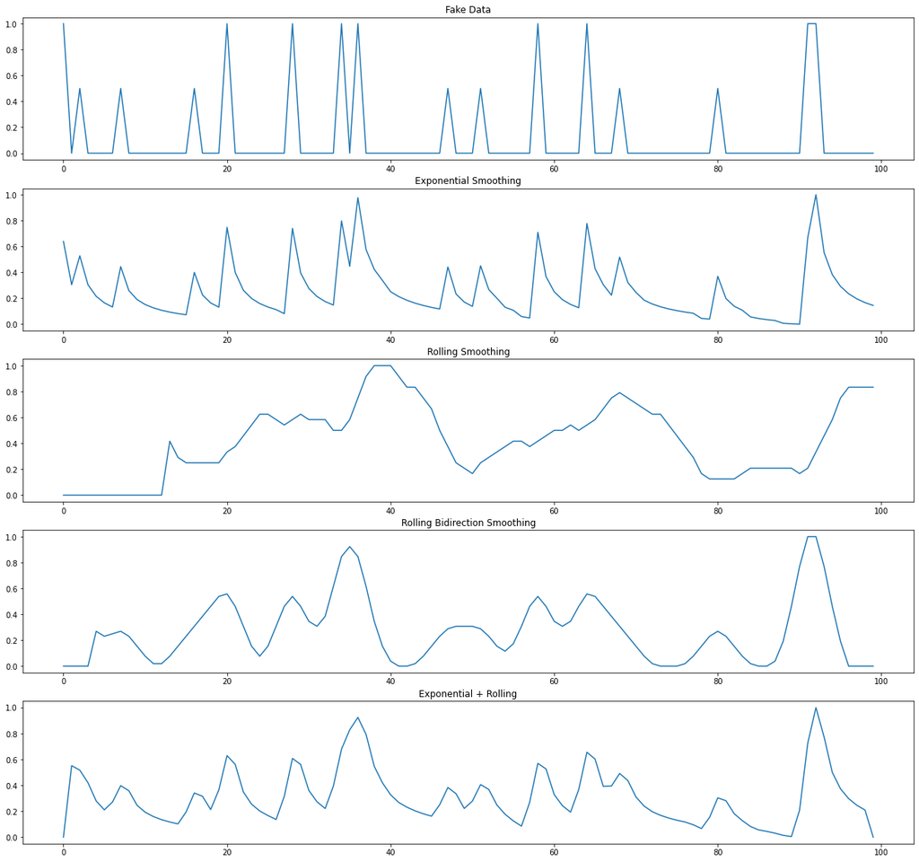

```python
# Testing it out on some fake data
fake_data = np.random.choice(3, 100, p=[0.85, 0.075, 0.075])

_scaled = scale( fake_data )
_exponential = smooth_exponent ( fake_data, d = 20 )
_rolling = smooth_rolling( fake_data, d=5 )
_rolling_bi = smooth_rolling_bidirection( fake_data, d=2 )
_exponential_rolling = smooth_rolling_bidirection( _exponential, d=1 )

fig, ax = plt.subplots(5,1)
ax[0].plot( _scaled ); ax[0].set(title="Fake Data")
ax[1].plot( _exponential ); ax[1].set(title="Exponential Smoothing")
ax[2].plot( _rolling ); ax[2].set(title="Rolling Smoothing")
ax[3].plot( _rolling_bi ); ax[3].set(title="Rolling Bidirection Smoothing")
ax[4].plot( _exponential_rolling ); ax[4].set(title="Exponential + Rolling")
fig.set_size_inches(21,20)
```

The above visualizaiton can help see what effects the smoothing techniques will have on the data. Exponsntial smoothing seems to mimich the observed behaviour of video views the closest, which would be highly advantagous. But at the same time it seems to make the data more rough, which is not helpful. Rolling smoothing smoothes out the data somewhat, but also shifts the events forward in time, meaing relational time data is somewhat lost. Doing a bi-direction rolling average corrects this time-shifting, but also allows some data to blead back in time which can give false results considering this is a time-seriese data comparison. Finally, in an atempt to get the best of both worlds, combining exponential with a small bi-direction rolling cuts drasticly down on the spikeyness of the data while not flattening it out as much as pure bi-direction. Lets use this for the analysis.

```python
# The final smoothing analysis
def smooth_time_data ( data ):
    return smooth_rolling_bidirection( smooth_exponent( data, d=20 ), d=2 )
```

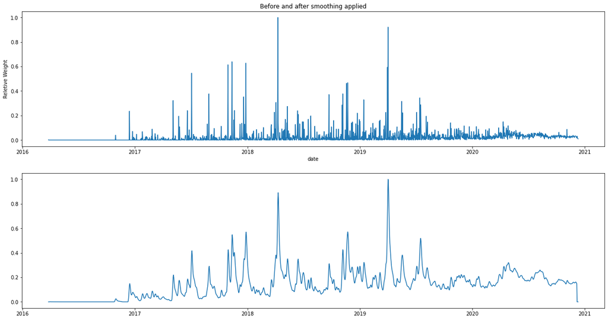

```python
# Now finally lets apply the smoothing back to the original chart x
_data = _unfilled.ave.fillna(0)
_smoothed = smooth_time_data(_data )
_original = scale(_data)

fig, ax = plt.subplots(2,1)
ax[0].plot(_original, label='Original')
ax[1].plot(_smoothed, label='Smoothed')
ax[0].set(title="Before and after smoothing applied", xlabel="date", ylabel="Reletive Weight")

fig.set_size_inches(21,11)
```

Though its still quite rough, the data is much cleaner and better captures the value of the data over time. There are not huge jumps or days with 0 video views as there were before. Furthermore we can still see that the major impactful videos are maintained as major spikes but not nearly as chaotic as before. We still see an increase over time, but this isnt nessesarily bad, certainly financial channels are gaining popularity over time and thus the weight graph should be increasing.

# Tag Analysis

## How to relate tags

Now that we have a reliable way to normalize the data over time, lets apply it to the tag date with the hope of drawing out some useful relations

```python
# Loading of tag_representation
tag_representation =  pd.read_csv( "./youtube_data/tag_view.csv" )
tag_representation = tag_representation[['date', 'tag', 'weight', 'vid', 'channel']].set_index('date')
tag_representation.index = pd.to_datetime(tag_representation.index)
tag_representation
```

| date | tag | weight | vid | channel |
| --- | --- | --- | --- | --- |
| 2018-11-16 | personalfinance | 389 | mQMkBhl6zFo | 40 Finance |
| 2018-11-16 | techstocks | 389 | mQMkBhl6zFo | 40 Finance |
| 2018-11-16 | financialplanning | 389 | mQMkBhl6zFo | 40 Finance |
| 2018-11-25 | stockmarket | 177 | 4u62lRmWlq8 | 40 Finance |
| 2018-11-25 | investing | 177 | 4u62lRmWlq8 | 40 Finance |
| ... | ... | ... | ... | ... |
| 2020-12-02 | whenaredividendspaidout | 2517 | fA_pAI3YFig | Honest Finance |
| 2020-12-02 | whenaredividendsissued | 2517 | fA_pAI3YFig | Honest Finance |
| 2020-12-02 | stockmarketinvesting | 2517 | fA_pAI3YFig | Honest Finance |
| 2020-12-02 | dividendinvesting | 2517 | fA_pAI3YFig | Honest Finance |
| 2020-12-02 | investingterms | 2517 | fA_pAI3YFig | Honest Finance |

225815 rows × 4 columns

```python
# Loading of daily weights
daily_weight = pd.read_csv( "./youtube_data/daily_weight.csv" )
daily_weight.columns = ['date', 'vids', 'weight', 'ave']
daily_weight = daily_weight.set_index('date')
daily_weight.index = pd.to_datetime(daily_weight.index)
daily_weight
```

| date | vids | weight | ave |
| --- | --- | --- | --- |
| 2016-03-26 | 22.0 | 203764.0 | 9262.000000 |
| 2016-03-27 | 22.0 | 203764.0 | 9262.000000 |
| 2016-03-28 | 22.0 | 203764.0 | 9262.000000 |
| 2016-03-29 | 22.0 | 203764.0 | 9262.000000 |
| 2016-03-30 | 22.0 | 203764.0 | 9262.000000 |
| ... | ... | ... | ... |
| 2020-12-06 | 548.0 | 52314373.0 | 95464.184307 |
| 2020-12-07 | 1026.0 | 178967634.0 | 174432.391813 |
| 2020-12-08 | 1530.0 | 145633909.0 | 95185.561438 |
| 2020-12-09 | 1752.0 | 146069772.0 | 83373.157534 |
| 2020-12-10 | 981.0 | 51611708.0 | 52611.323140 |

1721 rows × 3 columns

```python
# What are the most common tags?
_ = tag_representation.groupby('tag').count()
_ = _.sort_values( _.columns[0], ascending=False )[:10]
_ [ _.columns[0] ]
```

```
tag
stockmarket       3960
stocks            3872
investing         3175
money             1839
stockstobuy       1604
passiveincome     1480
news              1415
robinhood         1322
topstocks         1311
stockstobuynow    1270
Name: weight, dtype: int64
```

```python
# First, lets use the smoothing data we established before to look at a few tags over time
def get_performance ( _tag, start='2017-01-03', end='2020-12-05'):
    tag = _tag
    tag = tag_representation[ tag_representation.tag == tag ].groupby('date').sum().sort_index()
    tag = fill_empty_dates( tag ).fillna(0)
    tag['total_weight'] = daily_weight['weight']
    tag['share_of_weight'] = tag['weight'] / tag['total_weight']
    tag['smoothed_weight'] = smooth_time_data( tag['share_of_weight'] )
    tag = clamp_dates(tag.dropna(), start = start, end=end).fillna(0)
    return tag['smoothed_weight']

def clamp_dates (df, start='2017-01-01', end='2020-12-05'):
    dates = pd.date_range(start, end)
    return df.reindex(dates)
```

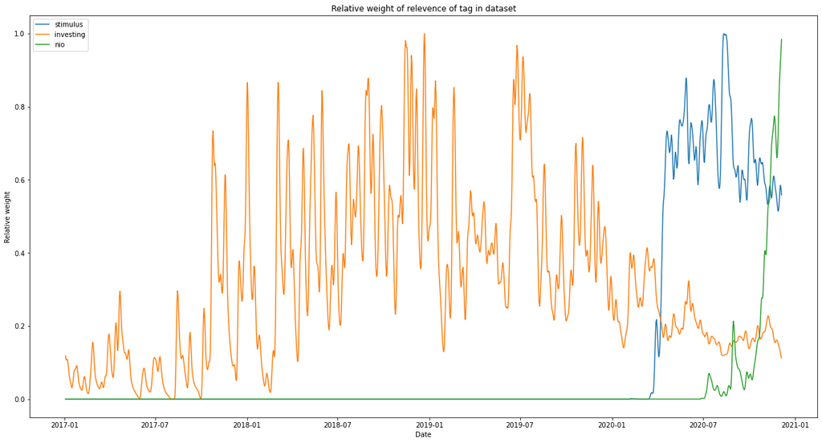

```python
# Plot out some of the tags and see what they look like
fig, ax = plt.subplots()
ax.plot( get_performance( 'stimulus' ) , label='stimulus')
ax.plot( get_performance( 'investing' ) , label='investing')
ax.plot( get_performance( 'nio' ) , label='nio')
ax.set(title='Relative weight of relevence of tag in dataset', ylabel='Relative weight', xlabel='Date')
ax.legend()
fig.set_size_inches(21,11)
```

Here we can see in more detail exactly what we are doing. Three different tags are graphed above, each represents a tag found on multiple videos across our dataset. The graph represents the weight of that tag over time as we calculted earlier. All tags are then scaled from 0 to 1 to fit into a single chart. In general, investing has died down in interest over the last few years while stimulus has become popular since covid started. Nio is an electric vehicle stock that became popular the last few months which is supported by the graph above.

But the graph above is hardly useful, what we really want to see is some coorilation between tags. Lets see if we can find some tags that are directly related to comapair to eachother.

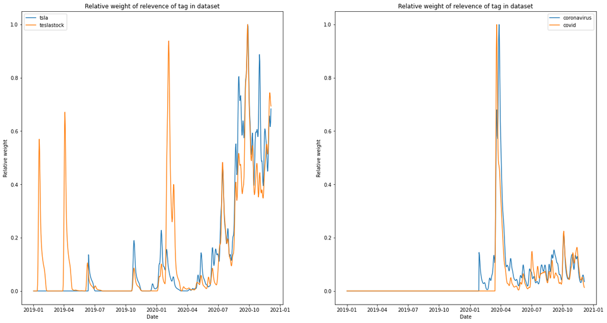

```python
# To visualize tags and their relations, we can graph similar tags against eachother and see how well they line up

a = get_performance( 'tsla' , start='2019-01-01')
b = get_performance( 'teslastock', start='2019-01-01' )
c = get_performance( 'coronavirus' , start='2019-01-01')
d = get_performance( 'covid', start='2019-01-01' )


# Plot them
fig, ax = plt.subplots(1,2)
ax[0].plot( a , label='tsla')
ax[0].plot( b , label='teslastock')
ax[0].set(title='Relative weight of relevence of tag in dataset', ylabel='Relative weight', xlabel='Date')
ax[0].legend()
ax[1].plot( c , label='coronavirus')
ax[1].plot( d , label='covid')
ax[1].set(title='Relative weight of relevence of tag in dataset', ylabel='Relative weight', xlabel='Date')
ax[1].legend()
fig.set_size_inches(21,11)
```

Here we can see two pairs of tags over time that coorilate well with eachother, expectedly. There is a clear relation between these pairs and no real relation across pairs.

```
C:\Users\Eric Robertson\.conda\envs\data_science\lib\site-packages\ipykernel_launcher.py:27: UserWarning: FixedFormatter should only be used together with FixedLocator
C:\Users\Eric Robertson\.conda\envs\data_science\lib\site-packages\ipykernel_launcher.py:28: UserWarning: FixedFormatter should only be used together with FixedLocator
```

|  | tsla | teslastock | coronavirus | covid |
| --- | --- | --- | --- | --- |
| tsla | 1.000000 | 0.553237 | 0.005885 | 0.004872 |
| teslastock | 0.553237 | 1.000000 | -0.067060 | -0.021450 |
| coronavirus | 0.005885 | -0.067060 | 1.000000 | 0.604601 |
| covid | 0.004872 | -0.021450 | 0.604601 | 1.000000 |

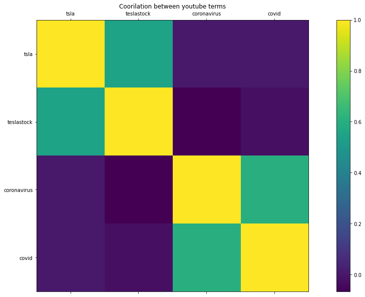

```python
# It would be really good if we could further understand this relation with a numerical measure, a good one is the pearson measure
_labels = ['tsla','teslastock','coronavirus','covid']
_tags = [a,b,c,d]
results = []

for tag1 in _tags:
    row = []
    for tag2 in _tags:
        first = max( tag1[tag1>0].index[0], tag2[tag2>0].index[0] )

        # Taking the diff here because we care about reletive movement and not absolute values
        _a = tag1[tag1.index >= first ].diff().dropna()
        _b = tag2[tag2.index >= first ].diff().dropna()

        # Calculate pearsonr value for the pair of seriese
        row.append(stats.pearsonr(_a,_b)[0])
    results.append(row)

# Store into a data frame
results = pd.DataFrame( results )
results.columns = _labels
results.index = _labels

#Plot it out
fig, ax = plt.subplots(1,1)
fig.colorbar( ax.matshow(results) )
ax.set_xticklabels(['']+_labels)
ax.set_yticklabels(['']+_labels)
plt.title('Coorilation between youtube terms')
fig.set_size_inches(20,10)

results
```

Now that is a very pretty chart! We see that `tsla` and `tsla` have a coorilation of 1, as they are the same tag. `tsla stock` and `tsla` have a high, but not 1 coorilation as we would expect. Tsla then has a terrible corrilation with the two covid tags. And the covid tags coorilate well with eachother. We should be able to use this metric to find other such pairs of coorilating tags.

We acomplish this all with the pearsonr measure that gives a output relating the coorilation between two sets of time serise data. Higher numbers indicate higher coorilation between the two dataset. We can use this going forward to get a better understanding of how stocks and tags relate.

Further reading on the peasorson measure is [here](http://mines.humanoriented.com/classes/2010/fall/csci568/portfolio_exports/sphilip/pear.html#:~:text=Similar%20to%20the%20modified%20Euclidean,data%20objects%20fit%20a%20line.)

## Mass Checking relations

```python
## Coorilation amung top tags
top_tags = tag_representation.groupby('tag').sum().sort_values('weight', ascending=False)[:100].index.values
top_tags
```

```
array(['stimuluscheck', 'stimuluschecks', 'stimuluspackage', 'investing',
       'howtoinvest', 'stimulus', 'passiveincome', 'howtoinvestinstocks',
       'investingforbeginners', 'stimulusbill', 'howtoinvestinrealestate',
       'secondstimuluscheck', 'stimulusupdate', 'secondstimulus',
       'stimuluscheckupdate', 'robinhood', 'realestateinvesting',
       'robinhoodapp', 'realestate', 'stockmarket',
       'stimulusunemployment', 'ndstimuluscheck', 'howtobeamillionaire',
       'howtobuildwealth', 'stimuluscheckround', 'stockmarketinvesting',
       'trump', 'creditscore', 'stimuluscheckstatus',
       'unemploymentstimulus', 'stocks', 'news', 'secondstimulusupdates',
       'creditscoreexplained', 'investinginyours', 'stimuluschecksecond',
       'secondstimuluscheckupdate', 'creditcard', 'caresact', 'ppploan',
       'beststocktradingapp', 'stimuluschecknews', 'heroesact',
       'stockmarketinvestingforbeginners', 'howtobeamillionaireinyears',
       'money', 'whensecondstimuluscheck', 'presidenttrump',
       'howtobuildwealthinyours', 'passiveincomeideas',
       'creditcardsforbeginners', 'unemployment',
       'howtomakepassiveincome', 'realestateinvestingforbeginners',
       'howtoinvestinyours', 'stimuluschecksecondround',
       'personalfinance', 'howtomakemoneyonline', 'stockoptions',
       'howtosavemoney', 'bloomberg', 'howtomakemoney', 'investment',
       'stimulustalks', 'bitcoin', 'senate', 'andreijikh', 'newstoday',
       'newstodaylive', 'newstodayusa', 'clearvaluetax',
       'investinginrealestate', 'market', 'investinginstocks', 'congress',
       'dividends', 'business', 'topaltcoins', 'crypto', 'house',
       'cryptocurrency', 'democrats', 'yahoofinance', 'dividendinvesting',
       'politics', 'irs', 'howtobecomeamillionaire', 'savings',
       'bestinvestment', 'stockstobuy', 'nowyouseeme',
       'willtherebeasecondstimuluscheck', 'republicans', 'bonds',
       'markets', 'executiveorders', 'taxes', 'howibecameamillionaire',
       'currencies', 'equities'], dtype=object)
```

```python
# Precompute for faster computation
tag_scores = [
    get_performance( tag )
    for tag in top_tags
]
```

```python
# Pairwise compair every tag in the top 100 with every other to see any interesting coorilations
results = []
for i,tag1 in enumerate(top_tags):
    print(f"{i}/{len(top_tags)} {tag1}".rjust(100,' '), end='\r')
    row = []
    for j,tag2 in enumerate(top_tags):
        if j < i : row.append(np.nan)
        elif j==i : row.append(np.nan)
        else:
            _1 = tag_scores[i]
            _2 = tag_scores[j]
            first = max( _1[_1>0].index[0], _2[_2>0].index[0] )
            _1 = _1[_1.index >= first ].diff().dropna()
            _2 = _2[_2.index >= first ].diff().dropna()
            row.append(stats.pearsonr(_1,_2)[0])
    results.append(row)
```

```
                                                                                 0/100 stimuluscheck
```

```
C:\Users\Eric Robertson\.conda\envs\data_science\lib\site-packages\scipy\stats\stats.py:3845: PearsonRConstantInputWarning: An input array is constant; the correlation coefficent is not defined.
  warnings.warn(PearsonRConstantInputWarning())
```

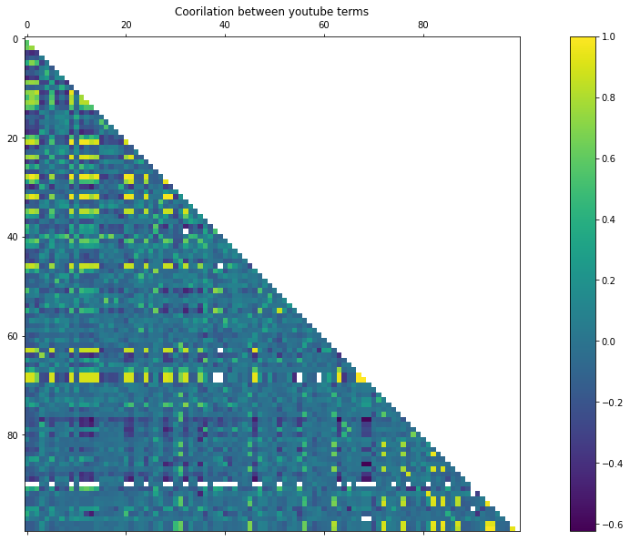

```python
# Lets see the results
result_table = pd.DataFrame( results ).T
result_table.columns = top_tags
result_table.index = top_tags

fig, ax = plt.subplots(1,1)
fig.colorbar( ax.matshow(result_table) )
plt.title('Coorilation between youtube terms')
fig.set_size_inches(20,10)
```

Though with the number of terms, the graph above is not particularly useful, it is quite pretty, so i included it. Enjoy.

In addition, we just did a pairwise comparison of the top 100 tags in our dataset to explore and see what kind of coorilation we are finding. Lets see what kind of output we are getting from all of these comparisons.

```python
coorilations = result_table.stack().reset_index().sort_values(0, ascending=False)
coorilations
```

|  | level_0 | level_1 | 0 |
| --- | --- | --- | --- |
| 2403 | newstodayusa | newstodaylive | 1.000000 |
| 2402 | newstodayusa | newstoday | 1.000000 |
| 2338 | newstodaylive | newstoday | 1.000000 |
| 4892 | equities | bonds | 0.991329 |
| 4893 | equities | markets | 0.983077 |
| ... | ... | ... | ... |
| 2984 | topaltcoins | newstodayusa | -0.603221 |
| 2983 | topaltcoins | newstodaylive | -0.603221 |
| 2978 | topaltcoins | stimulustalks | -0.607477 |
| 3712 | howtobecomeamillionaire | newstodaylive | -0.623927 |
| 3713 | howtobecomeamillionaire | newstodayusa | -0.623927 |

4898 rows × 3 columns

We are mostly seeing corilations within channels here as one channel may post videos with multiple tags and they then move together. Some interesting relations tho is the almost linear corilation between `equities` and `bonds`.

```python
# Lets see if we can see these relations directly
def compair_tags (a,b):

    _a = get_performance( a )
    _b = get_performance( b )

    first = max( _a[_a>0].index[0], _b[_b>0].index[0] )
    _a = _a[_a.index >= first ]
    _b = _b[_b.index >= first ]

    fig, ax = plt.subplots(2,1)
    ax[0].plot( _a , label=a, color='r')
    ax[1].plot( _b , label=b)
    ax[0].set_title(f'Comparison of {a} tag and {b} tag')
    ax[0].legend()
    ax[1].legend()

    fig.set_size_inches(11,11)
```

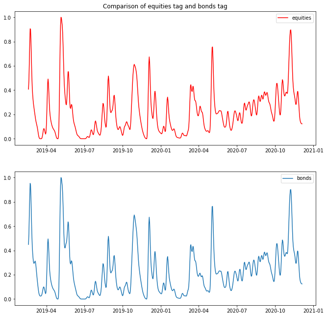

```python
compair_tags('equities', 'bonds')
```

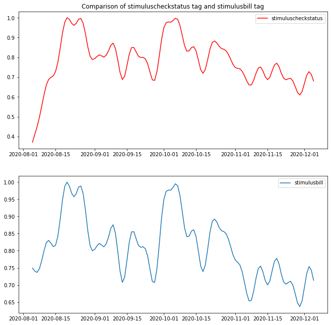

```python
compair_tags('stimuluscheckstatus', 'stimulusbill')
```

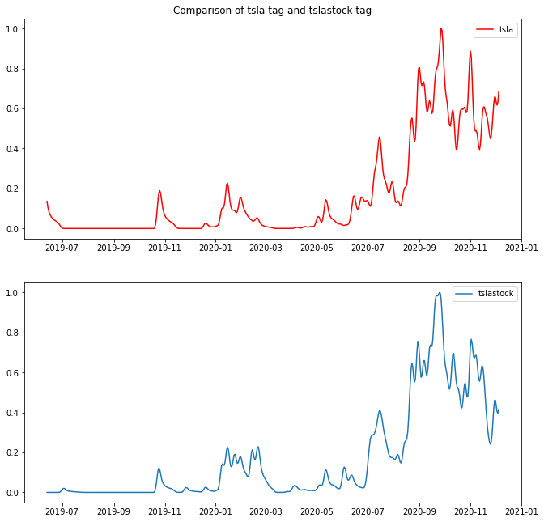

```python
compair_tags('tsla', 'tslastock')
```

# Stock Coorilations

Finally, lets check out the relations we got between the stocks and the tags we were exploring before

## Stocks coorilations with Tags

```python
# Load stocks
stocks = pd.read_csv( f"./stock_data/clean.csv" ).set_index('Unnamed: 0')
stocks.index = pd.to_datetime(stocks.index)
stocks
```

| Unnamed: 0 | NIO | WKHS | TSLA | AAPL | HYLN | SHLL | AMZN | DPHC | FB | SPY | ... | F | WYNN | INTC | SQ | ETSY | NVDA | SHOP | MRNA | JNJ | LMND |
| --- | --- | --- | --- | --- | --- | --- | --- | --- | --- | --- | --- | --- | --- | --- | --- | --- | --- | --- | --- | --- | --- |
| 2020-12-09 | 44.01 | 21.04 | 604.480 | 121.780000 | 17.94 | 17.94 | 3104.20 | 19.20 | 277.92 | 366.850000 | ... | 9.450000 | 111.160000 | 50.070000 | 207.04 | 159.23 | 517.230000 | 1038.19 | 156.59 | 153.100000 | 87.39 |
| 2020-12-08 | 46.56 | 21.36 | 649.880 | 124.380000 | 19.01 | 19.01 | 3177.29 | 19.37 | 283.40 | 370.170000 | ... | 9.250000 | 111.310000 | 50.690000 | 213.01 | 163.97 | 534.000000 | 1102.09 | 169.86 | 151.550000 | 90.60 |
| 2020-12-07 | 45.11 | 21.23 | 641.760 | 123.750000 | 19.31 | 19.31 | 3158.00 | 20.08 | 285.58 | 369.090000 | ... | 9.220000 | 111.320000 | 50.200000 | 212.58 | 156.93 | 544.270000 | 1084.40 | 159.52 | 148.970000 | 91.72 |
| 2020-12-04 | 43.04 | 22.07 | 599.040 | 122.250000 | 18.03 | 18.03 | 3162.58 | 23.47 | 279.70 | 369.850000 | ... | 9.340000 | 113.500000 | 51.985000 | 208.15 | 155.03 | 542.330000 | 1053.89 | 152.52 | 150.270000 | 85.04 |
| 2020-12-03 | 45.35 | 22.67 | 593.380 | 122.940000 | 18.04 | 18.04 | 3186.73 | 22.99 | 281.85 | 366.690000 | ... | 9.210000 | 108.490000 | 50.990000 | 205.53 | 154.74 | 535.840000 | 1062.68 | 157.26 | 149.000000 | 80.35 |
| ... | ... | ... | ... | ... | ... | ... | ... | ... | ... | ... | ... | ... | ... | ... | ... | ... | ... | ... | ... | ... | ... |
| 2017-01-09 | NaN | 5.71 | 46.256 | 28.169950 | NaN | NaN | 796.92 | NaN | 124.90 | 210.837560 | ... | 10.283541 | 85.868891 | 33.079227 | 15.06 | 12.35 | 105.977152 | 47.18 | NaN | 104.481893 | NaN |
| 2017-01-06 | NaN | 6.45 | 45.802 | 27.914268 | NaN | NaN | 795.99 | NaN | 123.41 | 211.535821 | ... | 10.389389 | 85.572632 | 32.961764 | 15.00 | 13.08 | 101.847915 | 46.90 | NaN | 104.499864 | NaN |
| 2017-01-05 | NaN | 6.75 | 45.350 | 27.606503 | NaN | NaN | 780.45 | NaN | 120.67 | 210.781687 | ... | 10.397531 | 84.656080 | 32.844302 | 14.56 | 12.40 | 100.504432 | 47.68 | NaN | 105.003044 | NaN |
| 2017-01-04 | NaN | 6.85 | 45.398 | 27.466825 | NaN | NaN | 757.18 | NaN | 118.69 | 210.949277 | ... | 10.723218 | 83.582140 | 32.898515 | 14.25 | 11.97 | 103.122249 | 44.14 | NaN | 103.915815 | NaN |
| 2017-01-03 | NaN | 6.89 | 43.398 | 27.497602 | NaN | NaN | 753.67 | NaN | 116.86 | 209.701720 | ... | 10.250973 | 80.971355 | 33.070191 | 13.81 | 11.88 | 100.771153 | 42.82 | NaN | 104.086537 | NaN |

994 rows × 22 columns

```python
# Get the compairisons ready by searching for comparison-ready tags
target_tags = [ (a+'stock').lower() for a in target_stocks ]
target_tags
```

```
['niostock',
 'wkhsstock',
 'tslastock',
 'aaplstock',
 'hylnstock',
 'shllstock',
 'amznstock',
 'dphcstock',
 'fbstock',
 'spystock',
 'msftstock',
 'googlstock',
 'fstock',
 'wynnstock',
 'intcstock',
 'sqstock',
 'etsystock',
 'nvdastock',
 'shopstock',
 'mrnastock',
 'jnjstock',
 'lmndstock']
```

```python
# Now lets compair tags with the stocks themselves
tag_scores = [
    get_performance( tag ).sort_index()
    for tag in target_tags
]
```

```python
# Utility function to compair a stock and a tag
def compair_stock_to_tag ( tag, stock ):
    rolling = 10

    _stock = stocks[stock].sort_index()
    _stock.index = pd.to_datetime(_stock.index)
    _stock = scale(_stock).rolling(rolling).sum()

    _tag = get_performance(tag).sort_index()
    _tag = scale(_tag)
    _tag = _tag.rolling(rolling).sum()

    _combined = pd.DataFrame([_stock, _tag]).T.dropna()
    _stock = _combined[ _combined.columns[0] ]
    _tag = _combined[ _combined.columns[1] ]

    return stats.pearsonr(_stock,_tag)[0], _stock, _tag
```

```python
# Lets compair every stock to every tag to see if we find anything
results = []
a = ''
for i,_stock_tag in enumerate(target_tags):
    row = []
    print(f"{_stock_tag} loading", end='\r')
    for j,_stock_name in enumerate(stocks.columns):
        if j < i : row.append(np.nan)
        else:
            value = compair_stock_to_tag ( _stock_tag, _stock_name)[0]
            row.append( value )
    results.append(row)
```

```
fstock loadingding
```

```
C:\Users\Eric Robertson\.conda\envs\data_science\lib\site-packages\scipy\stats\stats.py:3845: PearsonRConstantInputWarning: An input array is constant; the correlation coefficent is not defined.
  warnings.warn(PearsonRConstantInputWarning())
```

```
lmndstock loading
```

```python
result_table = pd.DataFrame( results ).T
result_table.columns = stocks.columns
result_table.index = target_tags

result_table.to_csv('./stock_data/tag_coorilation.csv')
```

```
C:\Users\Eric Robertson\.conda\envs\data_science\lib\site-packages\ipykernel_launcher.py:8: UserWarning: FixedFormatter should only be used together with FixedLocator

C:\Users\Eric Robertson\.conda\envs\data_science\lib\site-packages\ipykernel_launcher.py:10: UserWarning: FixedFormatter should only be used together with FixedLocator
  # Remove the CWD from sys.path while we load stuff.
```

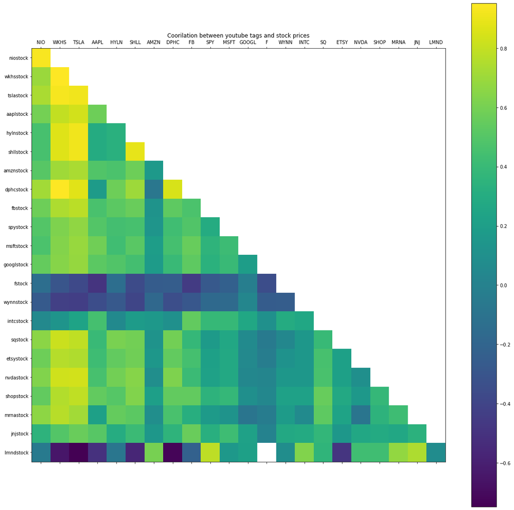

```python
column_names = list( stocks.columns )
column_names.insert(0,'_')
row_names = list( target_tags )
row_names.insert(0,'_')

fig, ax = plt.subplots(1,1)
fig.colorbar( ax.matshow(result_table) )
ax.set_xticklabels( column_names )
ax.xaxis.set_major_locator(ticker.MultipleLocator(1))
ax.set_yticklabels( row_names )
ax.yaxis.set_major_locator(ticker.MultipleLocator(1))
plt.title('Coorilation between youtube tags and stock prices')
fig.set_size_inches(20,20)
```

Clearly not as conclusive as would be idea. The key points to look at are those on the diagonal. These spots indicate the coorilation between the youtube tag and the stock ticker in question. For most its surprisingly unrelated. For a few it seems quite good though.

```python
# Explore full list of coorilation
coorilations = result_table.stack().reset_index().sort_values(0, ascending=False)
coorilations
```

|  | level_0 | level_1 | 0 |
| --- | --- | --- | --- |
| 2 | wkhsstock | WKHS | 0.952796 |
| 29 | dphcstock | WKHS | 0.946514 |
| 0 | niostock | NIO | 0.937149 |
| 4 | tslastock | WKHS | 0.932632 |
| 5 | tslastock | TSLA | 0.918920 |
| ... | ... | ... | ... |
| 234 | lmndstock | AAPL | -0.503009 |
| 236 | lmndstock | SHLL | -0.566833 |
| 232 | lmndstock | WKHS | -0.644459 |
| 238 | lmndstock | DPHC | -0.728213 |
| 233 | lmndstock | TSLA | -0.748472 |

252 rows × 3 columns

```python
# Char coorilations
def chart_comparison ( stock, tag ) :
    _, _stock, _tag = compair_stock_to_tag( tag, stock )

    fig, ax = plt.subplots(1,1)
    plt.plot( _stock , label='stock price')
    plt.plot( _tag , label='youtube tags')
    ax.set(xlabel = 'date')
    ax.legend()
    plt.title(f'{stock} Coorilation between youtube tags and stock prices')
    fig.set_size_inches(15,8)
```

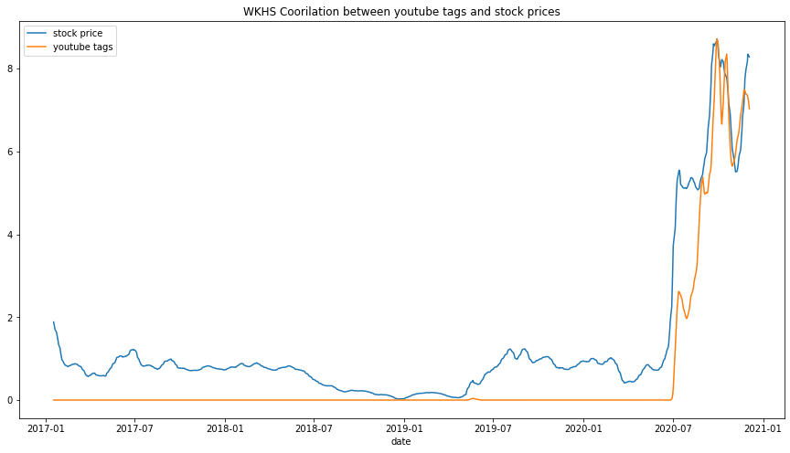

```python
chart_comparison( 'WKHS', 'wkhsstock')
```

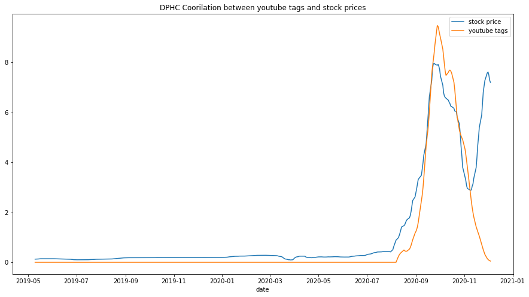

```python
chart_comparison( 'DPHC', 'dphcstock')
```

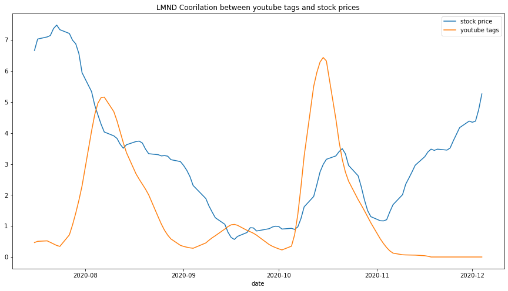

```python
chart_comparison( 'LMND', 'lmndstock')
```

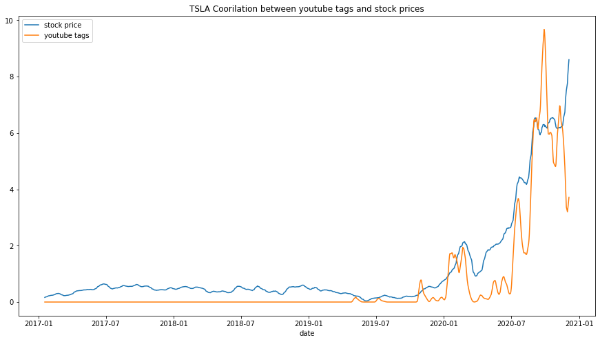

```python
chart_comparison( 'TSLA', 'tslastock')
```

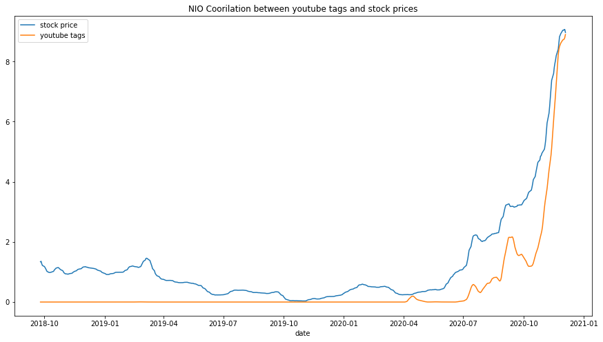

```python
chart_comparison( 'NIO', 'niostock')
```

## Do stocks predict the news?

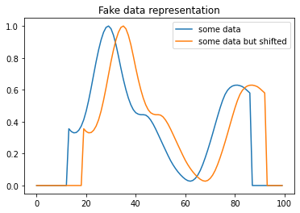

```python
# First lets understand what an alogorithm would look like for understanding prediction vs reporting
fake_data = smooth_rolling_bidirection( np.random.choice(3, 100, p=[0.85, 0.075, 0.075]) )
fake_data_2 = shift(fake_data, 6)

plt.plot(fake_data, label='some data')
plt.plot(fake_data_2, label='some data but shifted')
plt.title('Fake data representation')
plt.legend()
```

This chart above represents what may be a stock data from the market and a youtube data tag listing. We are aiming to understand a given youtube trend is a real prediction / influence on stock price or if it simply is a report on price changes. IE: Does youtube trends predict stock trends or simply mirror them. One way to assess this relationship is to compair how well a coorilation data forms at various shifts. Below I illistrate this more.

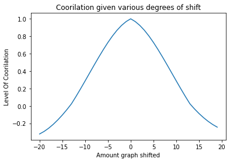

```python
# Define
def run_shift_similarity( data, n ):
    if n == 0:
        return 1
    else:
        a = data.fillna(0)
        b = shift(a, n)
        return stats.pearsonr(a,b)[0]

sims = []
for i in range(-20,20):
    _ = run_shift_similarity(fake_data, i)
    sims.append( _  )

plt.plot(range(-20,20), sims)
plt.title('Coorilation given various degrees of shift')
plt.xlabel('Amount graph shifted')
plt.ylabel('Level Of Coorilation')
fig.set_size_inches(15,8)
```

In this graph we can see the various levels of coorilation observed from a simple shift of one curve when compaired with itself. As the graph shifts to one side and then is compaired to the un-shifted version, it becomes a worse and worse match over time as illistrated above with 0 being the highest value. We can use this to test relation between stocks and tags. If we shift the tag graph to the right and the coorilation increases, we can see evidence that the tag is actively predicting the stock data. Similarly if we shift it left and gain coorilation then we gain evidence for a simple mirror of the stock price rather than active anticipation.

```python
# Implementing a forward and backward shift algorithm
def compair_stock_to_tag_with_shift ( tag, stock ):
    rolling = 10
    shift_amount = 15

    _stock = stocks[stock].sort_index()
    _stock.index = pd.to_datetime(_stock.index)
    _stock = scale(_stock).rolling(rolling).sum()

    _tag = get_performance(tag).sort_index()
    _tag = scale(_tag)
    _tag = _tag.rolling(rolling).sum()

    _combined = pd.DataFrame([_stock, _tag]).T.dropna()
    _stock = _combined[ _combined.columns[0] ]
    _tag = _combined[ _combined.columns[1] ]


    shift_back_score = stats.pearsonr(_stock, shift(_tag, -shift_amount))[0]
    plain_score = stats.pearsonr(_stock, _tag)[0]
    shift_forward_score = stats.pearsonr(_stock, shift(_tag, +shift_amount))[0]

    return shift_back_score, plain_score, shift_forward_score
```

```python
# Do that shift for each item in the dataset
results = []
for i,_stock_tag in enumerate(target_tags):
    _stock_name = stocks.columns[i]
    results.append( compair_stock_to_tag_with_shift( _stock_tag, _stock_name ))
```

```python
# Find relations, and label each as a prediction or a simple report of the data
_ = pd.DataFrame(results)
_.columns = ['back', 'plain', 'forward']
_.index = target_tags
_['gain'] = _['forward'] - _['back']
_['predict or report'] = np.where( _['gain'] > 0, 'predict', 'report' )
_.sort_values('gain')
```

|  | back | plain | forward | gain | predict or report |
| --- | --- | --- | --- | --- | --- |
| lmndstock | 0.102976 | 0.081461 | -0.374828 | -0.477804 | report |
| hylnstock | 0.547676 | 0.329702 | 0.224220 | -0.323456 | report |
| shllstock | 0.716479 | 0.889367 | 0.598081 | -0.118398 | report |
| fstock | -0.252769 | -0.348814 | -0.330412 | -0.077643 | report |
| googlstock | 0.183521 | 0.197019 | 0.130554 | -0.052967 | report |
| intcstock | 0.255557 | 0.266943 | 0.252458 | -0.003100 | report |
| aaplstock | 0.558533 | 0.579105 | 0.555670 | -0.002863 | report |
| nvdastock | 0.058167 | 0.099034 | 0.077868 | 0.019701 | predict |
| wkhsstock | 0.843719 | 0.952796 | 0.875450 | 0.031731 | predict |
| msftstock | 0.376103 | 0.417857 | 0.421501 | 0.045398 | predict |
| dphcstock | 0.663825 | 0.851075 | 0.711095 | 0.047270 | predict |
| mrnastock | 0.292798 | 0.421303 | 0.352097 | 0.059299 | predict |
| wynnstock | -0.317425 | -0.244353 | -0.250106 | 0.067319 | predict |
| amznstock | 0.102932 | 0.162179 | 0.173431 | 0.070499 | predict |
| jnjstock | 0.256225 | 0.341981 | 0.332242 | 0.076017 | predict |
| tslastock | 0.803230 | 0.918920 | 0.889692 | 0.086462 | predict |
| spystock | 0.252415 | 0.298018 | 0.349798 | 0.097382 | predict |
| etsystock | 0.158546 | 0.216841 | 0.262600 | 0.104054 | predict |
| fbstock | 0.366648 | 0.473635 | 0.496689 | 0.130041 | predict |
| shopstock | 0.327076 | 0.387442 | 0.473381 | 0.146304 | predict |
| sqstock | 0.317196 | 0.400609 | 0.477710 | 0.160514 | predict |
| niostock | 0.573203 | 0.937149 | 0.915477 | 0.342274 | predict |

```python
# How many were predictions vs reports
f"{len( _[_['predict or report'] == 'predict'] )} / {len(_)} of datapoints were more predictive than reporting"
```

```
'15 / 22 of datapoints were more predictive than reporting'
```

# Conclusion

## What complications were run into?

For the most part, a lack of data. With a quarter million tags over four years, i had hoped for more a clear outcome but the data was still much to noisy. For all but a few stocks, there simply was not enough data to make an impact. Further data could be scraped with more time but as it is currently more infromation can not really be pulled from what was found.

## Extentions?

NLP models could be deployed to help further give a better weight for each tag. Other sources like comments or captions for videos could be further deployed. In general, more stocks could be coorilated with more tags and more relations found.